# S2.8: il codice della griglia di Visium HD fa ciò che dice il suo documento di progetto, e quale funzione deve essere l’ingresso del simulatore?

geo_spatialtrans, report di step (protocollo v2)

Published

November 12, 2026

# In breve

### In breve: il codice della griglia di Visium HD fa ciò che dice il suo documento di progetto, e quale funzione deve essere l’ingresso del simulatore?

**A cosa serviva.** Prima di scrivere la guida d’uso e di unire lo Step 2 al ramo di sviluppo, dovevamo rivedere tutto il codice della griglia di Visium HD contro il suo documento di progetto. Dovevamo anche scegliere quale delle due funzioni di oggi diventa l’ingresso del simulatore: quella che simula l’area in un pezzo solo, scritta prima, o quella a pezzi, che regge anche il vetrino intero. Il modello non doveva cambiare: nessun conteggio simulato doveva muoversi.

**Cosa abbiamo trovato.**

1. **L’ingresso del simulatore sarà la funzione a pezzi: anche su un’area di 1 mm² costa poco più di quella in un pezzo solo.**
   - Lasciata lavorare in un solo pezzo, su 1 mm² impiega da un 3 % in meno a un 23 % in più del tempo della funzione vecchia, nei sei tessuti, e usa al più 6,2 GB.
   - Con i pezzi da mezzo millimetro, il valore predefinito, impiega da 85 secondi (cuore) a 4 minuti e mezzo (tumore del colon) e meno di 3,5 GB: dentro il bilancio in tutti i tessuti. La volta scorsa sembrava fuori bilancio per due ragioni: il server era carico, e la funzione vecchia riceveva già fatta la parte più lunga del calcolo.
   - La funzione vecchia resta nel pacchetto come riferimento per le prove.
2. **Nessun conteggio è cambiato.**
   - Abbiamo rifatto le simulazioni delle volte scorse con gli stessi semi. I file sono identici bit per bit, con la funzione a pezzi (pezzi da mezzo millimetro, da un millimetro o un pezzo solo) e con la funzione vecchia, anche dopo le ultime correzioni.
   - La prova vede una differenza quando c’è: cambiando di poco il tetto ai trascritti generati, i file cambiano in tutti i sei tessuti.
3. **Il documento di progetto era rimasto indietro in molti punti, il codice in pochi.**
   - Su 187 affermazioni del documento, 124 coincidevano con il codice. 37 erano superate da decisioni prese dopo, soprattutto la simulazione a pezzi, che il documento non conosceva: le ho annotate tutte con la loro fonte, senza cambiare nessuna regola.
   - 19 affermazioni erano giuste ma senza un test, quasi tutte valori dei parametri. Ora i parametri di tutti i tessuti sono controllati alla precisione scritta nel documento.
   - Il codice si scostava dal documento in 5 punti. Quattro erano già noti e ora sono chiusi o restano in coda; il quinto era un valore del fondo sul vetro che una funzione restituisce ancora ma che il simulatore non usa più: ora è scritto chiaro e provato.
4. **Una simulazione interrotta, se la si riprende, non può più mescolare risultati vecchi e nuovi.**
   - La funzione a pezzi salva un file per pezzo e, rilanciata nella stessa cartella, riusa quelli già fatti. Prima li riusava anche se nel frattempo erano cambiati il codice o i profili di espressione.
   - Ora si ferma e dice che cosa è cambiato. La revisione indipendente ha trovato un caso che mi era sfuggito: se cambiavano le cellule, per esempio i loro tipi, la ripresa restituiva in silenzio i conteggi vecchi. Ho corretto e provato anche questo.
5. **Su un’area ritagliata, il lato della finestra conta solo su una striscia sottile di vetro.**
   - Nell’intestino, dare al simulatore la finestra vera del ritaglio invece del contorno del tessuto cambia meno del 2 % i conteggi del tessuto e del vetro vicino.
   - Cambia solo la striscia di vetro larga 5 µm lungo il lato della finestra: da 0,4 a 1 UMI per quadratino. Lo scriveremo nella guida.

**Cosa devi decidere.** Niente: la scelta dell’ingresso l’ha presa la regola che avevi approvato prima della misura.

**Comunque**

- Il prossimo lavoro è sui documenti: la guida d’uso con la funzione a pezzi come ingresso, il README, il materiale per Daniele e l’unione nel ramo di sviluppo. All’apertura ti chiederò se unire anche il ramo principale, fermo al 2025.
- Su aree piccole il pezzo solo è più veloce dei pezzi da mezzo millimetro (da 1,1 a 1,2 volte). Far scegliere da sé al simulatore la grandezza dei pezzi è un’ottimizzazione che faremo insieme a quella del livello delle cellule, già in coda.
- Quando torneremo sul codice dei passi della griglia faremo tre cose rimaste annotate: verificare la forma delle strisce, provare che la posizione dei trascritti non dipende dal gene, scrivere i test di alcuni argomenti interni.

Non c’è nulla da decidere: se non hai dubbi, lo step è chiuso.

**Sui tempi di calcolo.** Li ho misurati io sul server: 81 simulazioni in 3,9 ore-processo (la stima era 6), 44 minuti di orologio con 6 processi, temperatura al massimo 86 °C. A parte, le batterie dei test, rifatte tre volte dopo le correzioni.

# Dubbi rinviati

| cosa | perché | cosa serve per chiuderlo | step destinatario | voce di BACKLOG |
| --- | --- | --- | --- | --- |
| guida d’uso della funzione a pezzi (riquadro `frame`, fondo con il fattore tagliato, lato dei pezzi per aree piccole e sezioni, `.geo_version()` che legge la `DESCRIPTION` della cartella di lavoro) | i documenti sono il perimetro di S2.8b (DEC-078) | guida, README, CLAUDE.md | S2.8b | BL-248 |
| parità delle strisce solo separabile, mai verificata | serve una misura sulle cinque sezioni | quattro classi di parità contro il prodotto | da assegnare | BL-249 |
| posizione dei trascritti indipendente dal gene senza test | lavoro sul codice dei passi | un test | primo step che tocca il codice dei passi | BL-250 |
| argomenti dei passi senza test | lavoro sul codice dei passi | test o argomenti non esportati | primo step che tocca il codice dei passi | BL-251 |
| scelta automatica del lato dei pezzi (il pezzo solo è da 1.08 a 1.24 volte più veloce su 1 mm²) | ottimizzazione | lato dai trascritti attesi per pezzo | S1.7 | BL-252 |
| memoria interna di Box-Muller non ripristinata | già in coda da S2.5 | come scritto nella voce | da assegnare | BL-238 |

# Cancelli, previsioni e controprova

Pre-registrazione: cancelli `e03f6bd`; ok di Luca sulle previsioni, sulla regola dell’ingresso con la soglia di 1.5 e sul calcolo il 2026-11-11 («Ok, come proposte (Recommended)»), commit `466563f`. Codice delle esecuzioni `1ecf81c`; codice finale dopo la revisione `64cf92f` e successivi (G-2 bis). File dello step: `docs/steps/S2.8.md`.

Tabelle in `results/S2.8/`: `S2.8_G1_summary.txt` e `S2.8_G1_test_S2.*.txt`, `S2.8_mutants.txt`, `S2.8_G2_identity.csv`, `S2.8_design_map.csv`, `S2.8_design_map_actions.csv`, `S2.8_exported_args.csv`, `S2.8_md5_before.txt`, `S2.8_md5_after.txt`, `S2.8_R_changed.txt`, `S2.8_runs.csv`, `S2.8_summary.csv`, `S2.8_predictions.csv`, `S2.8_rule_R1.csv`, `S2.8_rule_R1.json`, `S2.8_rule_R1_sens_k12.csv`, `S2.8_times_by_seed.csv`, `S2.8_BL237.csv`. Uscite grezze in `/mnt/micron/geo_spatialtrans/S2.8/` (81 esecuzioni, `sched.log`). Codice delle esecuzioni: commit `1ecf81c` (le modifiche successive, `21fc08f`, sono solo commenti e test).

### Cancelli

- **G-1** superato: sul codice delle esecuzioni `test_S2.8.R` 43/43 e mutanti 3/3; sul codice finale, dopo le correzioni della revisione, `test_S2.8.R` 46/46 (gruppi a, b, c 21; gruppo d 25) e mutanti 4/4 (dopo la correzione di due modelli di sostituzione rimasti alla riga di prima, D-8); batterie di S2.1…S2.7 con le stesse asserzioni di S2.7 (21, 36, 39, 37, 40, 33, 78), nessun FAIL, nessuna asserzione cambiata.
- **G-2** superato: 1 080 confronti di impronte su 1 080 come attesi (E504 contro S2.7: 324; E1008 ed EInf contro E504: 342 + 342; motore di S2.5 contro le uscite salvate di S2.5 e S2.7: 72). **G-2 bis** con il codice finale (`64cf92f`): le 6 esecuzioni E504 con k = 0 rifatte, 84 impronte su 84 uguali a S2.7 (`results/S2.8/S2.8_G2bis_final_code.csv`).
- **G-3** superato: mappa di 187 righe (124 coerenti, 37 documento indietro, 19 senza test, 5 codice diverso, 2 non chiare); le 63 righe non coerenti hanno tutte un’azione (39 annotazioni nella v0.6, 18 test aggiunti, 2 difetti corretti con test, 1 documentazione corretta con test, 1 documentata e misurata, 2 voci di BACKLOG); documento di progetto v0.6; controllo OKF 0 documenti in errore.
- **G-4** superato: 375 file letti identici prima e dopo; `R/` cambiato solo in `05b5`, `05b6` (perimetro), `05b2`, `05b3` (C-3, solo commenti) e nei test; `R/04b*.R` identici.
- **G-5** superato dopo le correzioni: due revisori, nessuna discrepanza numerica nei cancelli, nelle previsioni e nella regola; un difetto del codice (impronta senza il livello cellulare) e testi corretti (sotto «Revisione avversariale»).

### Previsioni

| id | giudizi | conf. | indet. | smentite | in breve |
| --- | --- | --- | --- | --- | --- |
| P-1 tempo della funzione a pezzi con 504 µm su 1 mm² | 6 | 6 | 0 | 0 | da 85 s (cuore) a 270 s (tumore del colon), 2 errori standard al più 5.4 s |
| P-2 picco di memoria con 504 µm | 6 | 6 | 0 | 0 | da 1.3 GB (cuore) a 3.2 GB (tumore del colon) |
| P-3 picco di memoria in un pezzo solo | 6 | 6 | 0 | 0 | da 1.7 GB (cuore) a 6.2 GB (tumore del colon); cervello 4.8 GB |

Attese sbagliate (le previsioni sono giudicate sugli intervalli, che restano quelli scritti): il tumore in P-1 e tumore e cervello in P-3 erano attesi fuori dal bilancio. P-1: i 385 s di S2.7 erano misurati con 16 processi sulla macchina; con 6 il tumore sta a 270 s. P-3: la stima di 9-10 GB scalava il picco dei quadrati di 4 mm² con il numero di quadratini della griglia (0.375), ma la memoria segue i trascritti, cioè il tessuto: 1 mm² contro 4 mm² (0.25), cioè circa 6.8 GB nel tumore, vicino ai 6.2 misurati.

### Regola dell’ingresso (R-1)

| tessuto | motore di S2.5 (s) | migliore a pezzi | tempo (s) | rapporto | con 504 µm |
| --- | --- | --- | --- | --- | --- |
| intestino | 160.9 | pezzo solo | 180.0 | 1.12 | 1.35 |
| tumore del colon | 212.1 | pezzo solo | 217.7 | 1.03 | 1.27 |
| stroma | 123.6 | pezzo solo | 132.3 | 1.07 | 1.28 |
| linfonodo | 173.2 | pezzo solo | 189.8 | 1.10 | 1.19 |
| cervello | 146.0 | pezzo solo | 180.1 | 1.23 | 1.51 |
| cuore | 78.8 | pezzo solo | 76.5 | 0.97 | 1.08 |

Rapporto ≤ 1.5 in 6 tessuti su 6: **un solo ingresso, `simulate_visium_hd_pieces()`**; il migliore non è 504 µm in nessun tessuto, quindi la scelta automatica del lato è una voce di BACKLOG (BL-252). Decisione tecnica: S2.8: l’ingresso del simulatore dello Step 2 è la funzione a pezzi; la funzione di S2.5 resta come motore di riferimento (DEC-079). Picco del motore di S2.5 con blocchi di 4 × 10⁶: da 3.4 a 7.4 GB, più del pezzo solo della funzione a pezzi.

### Controprova

- **CP-1** superata: la mappa, fatta senza sapere quali sezioni ci aspettavamo, segna come indietro le sezioni 1 (M-005, M-015, M-016), 12 (M-134…M-141) e 15 (M-163), più la 16 e, in parte, altre nove.
- **CP-2** superata: con `ceiling_q = 1e-4` l’impronta di `counts_2um` cambia in 6 tessuti su 6.

### Misure (senza intervallo)

- Tempi medi (s) per configurazione e tessuto, nell’ordine intestino, tumore, stroma, linfonodo, cervello, cuore: pezzi di 1 008 µm 211, 259, 154, 206, 221, 81; picchi (GB) motore di S2.5 5.8, 7.4, 5.3, 3.4, 5.9, 4.9; pezzi di 1 008 µm 3.7, 4.7, 2.8, 2.3, 4.8, 1.5 (`S2.8_summary.csv`).
- **Descrittiva di BL-237** (intestino A1_r1, 3 semi appaiati, finestra di R2 contro riquadro predefinito; distanze dal bordo sinistro del tessuto riga per riga, definizione corretta dopo la revisione dei numeri, vedi «Revisione avversariale»). Il bordo sinistro del tessuto è irregolare: il primo quadratino di tessuto di una riga sta da 6.5 a 184 µm dal lato della finestra (mediana 54 µm), e tocca il riquadro predefinito (x = 5.5 µm) solo nel 2.4 % delle righe. UMI medio per quadratino nel tessuto: 29.587 con il predefinito, 29.584 con la finestra (rapporto da 0.9998 a 1.0000 fra semi); nelle fasce di 0-8, 8-16, 16-32, 32-64 µm dal bordo (da 1 846 a 7 188 quadratini) rapporti da 0.997 a 1.002; vetro entro 8 µm dal bordo del tessuto 0.998; vetro fra il lato della finestra e il tessuto (17 231 quadratini) 1.02; striscia di vetro larga 5.5 µm lungo il lato della finestra, fuori dal riquadro predefinito (2 352 quadratini), da 0.38 a 0.98 UMI per quadratino (rapporto da 2.51 a 2.79): con il predefinito la seconda coda si ripiega a 5.5 µm e la striscia non la riceve. Vetro fuori dalla finestra 0.030 in entrambi. Conclusione: il riquadro conta solo su quella striscia; nel tessuto e nel vetro vicino al tessuto la differenza è sotto il 2 %. Il vero della striscia non è noto (D-3).

## Figure

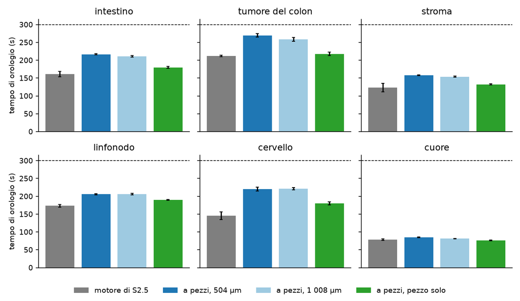

Tempo di orologio di una simulazione di un’area di 1 mm², media di 3 semi ± 2 errori standard, per configurazione e tessuto. Tratteggio: bilancio del documento di progetto (300 s).

**Cosa guardare**: le barre blu (valore predefinito, P-1) stanno sotto il tratteggio in tutti i tessuti; la barra verde (pezzo solo) è la più bassa delle configurazioni a pezzi e vicina a quella grigia del motore di S2.5 (regola R-1).

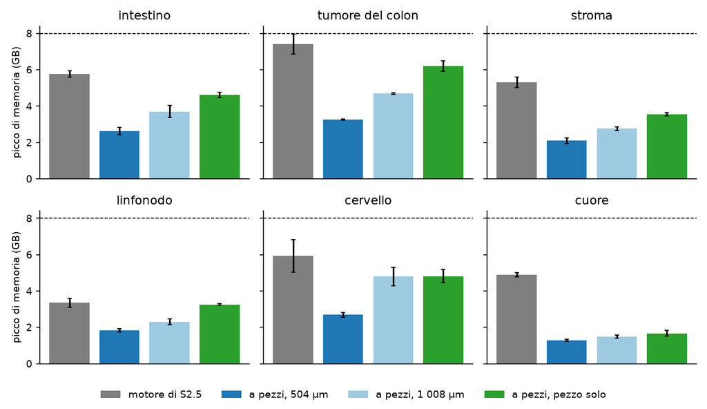

Picco di memoria, massimo sui 3 semi ± 2 errori standard. Tratteggio: bilancio (8 GB).

**Cosa guardare**: tutte le configurazioni a pezzi stanno sotto 8 GB (P-2, P-3); il pezzo solo arriva a 6.2 GB nel tumore del colon, il motore di S2.5 con blocchi di 4 × 10⁶ trascritti a 7.4 GB.

# Correzioni dichiarate prima dei verdetti

- **C-1, impronta del codice estesa alle costanti.** Nella prima esecuzione di sviluppo della batteria il test a3 è fallito: modificava `.p27_rows()`, una funzione che la funzione a pezzi non chiama (codice morto, tolto). Cercando le funzioni rimaste fuori dall’impronta è emerso che la funzione a pezzi legge una costante, la tabella `.s23_ztab`, che l’impronta (solo funzioni) non copriva: l’impronta ora include le costanti dello stesso ambiente lette dal codice, e la batteria ha il test a3b. Scelta tecnica in S2.8: impronta della ripresa con codice, costanti e profili; nomi della sovra-generazione uguali nei due motori; versione dalla DESCRIPTION (DEC-080).
- **C-2, test del gruppo d** (`R/testing/test_S2.8_d.R`, 25 asserzioni), aggiunti dopo la mappa come previsto da G-1 (d): valori della tabella dei parametri alla precisione scritta nel documento, cuore con la mediana delle altre sezioni, tumore e stroma sulla stessa sezione, fondo dei due motori da `capture_params()`, argomenti della funzione a pezzi senza test (`ceiling_q`, `assemble`, `keep_profiles`, `archetype`, `verbose`).
- **C-3, file di `R/` toccati per i difetti della mappa** (G-4): `R/05b3_place_and_move_transcripts.R` (intestazione di `transcript_params()`: il campo `b` è il fondo di R5, non usato dal simulatore; riga M-106) e `R/05b2_simulate_cell_profiles.R` (documentazione degli argomenti `chunks` e `streams`). Solo commenti roxygen: l’impronta del codice non cambia.

# Revisione avversariale

Due sotto-agenti con codice proprio, in sola lettura (2026-11-11; tabelle dei loro controlli negli artifact della sessione):

- **Numeri** (588 controlli, nessuna deviazione dichiarata): G-2 rifatto byte per byte (378 confronti in Python, 96 con `cmp`) e con le impronte (1 086 valori riderivati dai file), 0 differenze; P-1…P-3, R-1 e la sensibilità senza k = 0 identici; G-4 identico (375 file, `md5sum -c` rifatto); differenze di `R/05b2` e `R/05b3` solo commenti. Discrepanze, tutte di testo, corrette: (1) le fasce della descrittiva di BL-237 erano misurate dalla retta x = 5.48 µm, che tocca il tessuto solo nel 2.4 % delle righe: analisi rifatta con il bordo riga per riga (stessi numeri del revisore: fasce di 1 969, 1 846, 3 645, 7 188 quadratini, rapporti da 0.997 a 1.002), testo riscritto; (2) D-2 contava 13 esecuzioni toccate invece di 9 (finestra più larga del vero); (3) temperatura massima 85.6 °C, non 84; (4) e (5) ordine di due medie e un arrotondamento (0.030).
- **Codice e documenti** (93 controlli; batteria e mutanti letti dai file, non rifatti, per regola del compito): nessuna via per cui una modifica del codice usato oggi sfugga all’impronta. Discrepanze: (A15) **l’impronta della ripresa non vedeva il livello cellulare**: con i tipi di 1 474 cellule scambiati (stessi centri) la ripresa restituiva in silenzio i conteggi vecchi, contro quanto scritto in S2.8: impronta della ripresa con codice, costanti e profili; nomi della sovra-generazione uguali nei due motori; versione dalla DESCRIPTION (DEC-080): corretto (impronta del livello: identificativi, tipi, centri, territori, nuclei, regioni; test a9; mutante M4); (A05, A06, A14) impronte diverse con la lingua di sistema C (ordine dei nomi, intestazione della serializzazione): corretto (ordine radix, serializzazione versione 2; test a11 con due processi nuovi); (A09, A10, A13) un oggetto dell’utente con il nome di una funzione di base cambiava l’impronta (rifiuto inutile): corretto (le chiamate cercano solo funzioni; test a10); (A24) costanti a 15 cifre: ora 17; (A28) test b4 tautologico: riscritto (trascritti generati con e senza strisce nel rapporto M*); (A29) test d4 controllava il valore scritto, non l’estrazione: riscritto (totale del fondo contro b c per quadratino); (A30) gruppo d saltato in silenzio se il file manca: ora FAIL; (B19, B20) nota della sezione 12 del documento di progetto (picco per pezzo «sotto 4 GB con 504 µm in tutti i tessuti», «34 GB»): falso per le sezioni dell’intestino, del linfonodo e del cuore, mai girate con 504 µm, e 34 GB è il valore con 1 008 µm (40 GB con 504): nota e S2.8: l’ingresso del simulatore dello Step 2 è la funzione a pezzi; la funzione di S2.5 resta come motore di riferimento (DEC-079) punto 3 riscritti; (B28) S2.5: il confronto fra simulato e vero si fa sugli stessi quadratini dei due lati (regioni dello Step 1, a distanza dal bordo dell’area) (DEC-064) mancante nella nota della sezione 16: aggiunta; (A01) C-2 e C-3 dichiarati dopo il commit dei file: deviazione D-6. Accolti senza modifica: `metadata$step` resta «S2.7» (passo che ha introdotto la funzione); `.geo_version()` legge la `DESCRIPTION` della cartella di lavoro (fuori dalla radice del repository dice «versione sconosciuta», l’impronta del codice resta): da scrivere nella guida (S2.8b). Campione della mappa (seme 2808, 15 righe coerenti e 10 no): nessuno stato sbagliato, tutte le azioni fatte.
- Dopo le correzioni: batteria, mutanti e batterie di S2.1…S2.7 rifatti sul codice finale, e le 6 esecuzioni con k = 0 rifatte con il codice finale contro S2.7 (G-2 bis), esiti sotto «Esiti».

# Cosa è girato

- Commit: cancelli `e03f6bd`, ok di Luca `466563f`, codice delle esecuzioni `1ecf81c`, correzioni della documentazione e test del gruppo d `21fc08f`, documento v0.6 e decisioni `0bb19ad`, correzioni dalla revisione `64cf92f`; chiusura nel commit «S2.8: esiti, revisione, In breve, report».
- Script: `tools/S2.8_run.R` (esecuzioni), `tools/S2.8_sched.py` (al più 6 processi), `tools/S2.8_analysis.py`, `tools/S2.8_identity.R`, `tools/S2.8_G2bis.py`, `tools/S2.8_md5.sh`, `tools/S2.8_mutants.sh`, `tools/S2.8_report_parts.py`; batteria `R/testing/test_S2.8.R` e `test_S2.8_d.R`.
- Semi: quelli di P-1 di S2.7 e del pannello di S2.5 (`/mnt/micron/geo_spatialtrans/S2.8/seeds.json`).
- Durata: 81 esecuzioni, 3.9 ore-processo, 19:59-20:43 del 2026-11-11.
- Integrità: 375 file letti, md5 identici prima e dopo (`results/S2.8/S2.8_md5_before.txt`, `_after.txt`).

# Appendice

## Perimetro

1. **Revisione d’insieme del ramo contro il documento di progetto.** Il documento di progetto dello Step 2 è alla v0.5 (scritta in S2.5). Una mappa riga per riga: sezione del documento (1-17) → funzione e argomento in `R/05b*.R` → test in `R/testing/test_S2.*.R` → step che l’ha verificata. Ogni scarto si classifica: (i) difetto del codice, corretto con un test; (ii) documento rimasto indietro, annotato nella v0.6 con la sua fonte (step o decisione); (iii) voce di BACKLOG. Anche ogni argomento esportato delle funzioni dello Step 2 deve avere un test che lo usa, oppure una voce di BACKLOG. La mappa la fa un sotto-agente in sola lettura; le correzioni le fa questa sessione.
2. **Ingresso del pacchetto** (regola R-1 sotto, misura P-1…P-3). Nessuna funzione si toglie: `simulate_visium_hd()` resta comunque come motore di riferimento delle batterie di S2.5 e S2.6. Nessun valore predefinito cambia in questo step (il lato di 504 µm di S2.7: pezzi da 504 µm come lato predefinito della simulazione a pezzi (DEC-076) resta).
3. **BL-247**: nell’impronta di `simulate_visium_hd_pieces()` entrano un’impronta del codice (le funzioni dello Step 2 che la funzione chiama) e un’impronta dei profili; `metadata$package_version` si legge da `DESCRIPTION` invece di essere scritta a mano («S2.7»); nomi della sovra-generazione allineati fra i due motori (`truth$layers$stripes$M` = sovra-generazione usata, come in `simulate_visium_hd()`; il massimo grezzo con un nome suo). I conteggi non cambiano (G-2).
4. **BL-248**: documentazione roxygen di `frame` (vale per la riflessione della seconda coda e per la distanza dal bordo del tessuto) e del fondo (Poisson con il fattore di striscia tagliato al tetto); descrittiva di BL-237.
5. **Documento di progetto v0.6**: sezioni 1, 12, 15, 17 e il resto che la mappa trova indietro; solo annotazioni con la fonte, nessuna regola nuova.

Fuori perimetro, dichiarato: README, CLAUDE.md, guida d’uso, materiale per Daniele e unione in `dev` (S2.8b); ottimizzazioni (S1.7, BL-243, BL-246); la scelta automatica del lato dei pezzi (se la misura la suggerisce, diventa una voce di BACKLOG per S1.7); le voci lasciate fuori dalla sequenza da Dopo S2.5 si fa prima una prova di prestazione su aree grandi; ordine e perimetro delle sessioni successive li prepara l’agente (DEC-071) punto 4 (densità dei preset, variabilità fuori dal nucleo, semi delle funzioni dei passi, migrazione dei documenti).

## Stime di preparazione

- **E-0, aree di 1 mm² in S2.7 (P-1)**, 16 processi sulla macchina, carico 15-26: funzione a pezzi (504 µm, 16 pezzi per area) mediana sui semi da 108 s (cuore) a 385 s (tumore del colon), picco massimo fra processo principale e pezzi da 1.2 a 3.9 GB; motore di S2.5 da 29 s a 238 s, picco da 3.3 a 8.3 GB (blocchi di 4 × 10⁶ trascritti). **Il confronto non è equo**: in S2.7 il motore di S2.5 riceveva griglia e verità geometrica già calcolate (`hd` delle aree di S2.3: 0.01 s per la griglia), mentre la funzione a pezzi le calcola; in S2.7 la verità geometrica pesa dal 17 al 69 % del tempo della funzione a pezzi. In questo step i due motori calcolano tutto.
- **E-1, quadrati di 4 mm² in S2.7 (G-2)**: la funzione a pezzi in un pezzo solo arriva a 27.3 GB nel tumore e 24.2 GB nel cervello (3.2 GB nel cuore); con pezzi di 504 µm il processo principale (cucitura) arriva a 11.9 GB nel tumore e 8.5 nell’intestino. Su 1 mm² (griglia di 0.61 milioni di quadratini contro 1.64) il pezzo solo potrebbe superare 8 GB nel tumore e nel cervello: lo dice P-3.

## Regola dell’ingresso

Misura: sulle sei aree di 1 mm² di P-1 di S2.7 (prima area di ogni tessuto: intestino A1_r1, tumore del colon A2_r1, stroma A3_r1, linfonodo A4_f1, cervello A5_r1, cuore A6_r1), 3 semi, quattro configurazioni: motore di S2.5 che calcola da sé griglia e verità geometrica (E0); funzione a pezzi con pezzi di 504 µm (E504), 1 008 µm (E1008), un pezzo solo (EInf). Un processo per esecuzione, un thread, al più 6 esecuzioni insieme, nessun altro utente sulla macchina.

- t(a, E) = media dei 3 tempi di orologio; picco(a, E) = massimo sui semi del picco di memoria residente (processo principale e processi dei pezzi).
- migliore(a) = la configurazione a pezzi più veloce fra E504, E1008, EInf con picco ≤ 8 GB; rapporto(a) = t(a, migliore) / t(a, E0).
- **Se rapporto ≤ 1.5 in almeno 5 tessuti su 6**: `simulate_visium_hd_pieces()` diventa l’unico ingresso documentato (la guida di S2.8b dice quale lato usare per aree piccole e per sezioni intere). **Altrimenti**: due ingressi documentati, `simulate_visium_hd()` per aree singole fino a circa 1 mm² e `simulate_visium_hd_pieces()` per aree più grandi e aree di cattura intere, con la nota che a parità di seme i due motori danno realizzazioni diverse della stessa legge (S2.7, P-1).
- Se migliore(a) non è E504 in almeno 5 tessuti su 6, la scelta automatica del lato dei pezzi diventa una voce di BACKLOG per l’ottimizzazione (S1.7), con il guadagno misurato.

Perché 1.5 (scelta tecnica dell’agente, da registrare come decisione con il risultato): un confronto di metodi ripete la simulazione da decine a centinaia di volte per tessuto. Oltre una volta e mezza il costo del motore di S2.5, un secondo ingresso per le aree piccole ripaga la sua complessità; sotto, conta di più avere un solo motore, il cui risultato non dipende da come si divide l’area (S2.7, G-2). Le sezioni intere non entrano nella regola: le fa solo la funzione a pezzi (S2.6: il motore di S2.5 non regge in memoria il tumore e il cervello, gli altri tre con 26-107 GB).

## Attese pre-registrate

Commit dei cancelli: `e03f6bd` (perimetro, stime di preparazione, regola R-1, cancelli e Il consolidamento dello Step 2 si fa in due step: S2.8 per il codice, S2.8b per i documenti e l’unione nel ramo di sviluppo (DEC-078)). Ok di Luca sulle previsioni P-1…P-3, sulla regola R-1 con la soglia di 1.5, sulla controprova e sul calcolo di circa 6 ore-processo: 2026-11-11, «Ok, come proposte (Recommended)».

Semi: quelli di P-1 di S2.7, k = 0, 1, 2 per area: funzione a pezzi dalla tabella `tasks_P1.json` di S2.7 (variante «new»); motore di S2.5 k = 0, 1 dai json di `S2.5/panel/main_r2/` e k = 2 da `tasks_P1.json` (variante «old»). Nessun seme nuovo: tutte le esecuzioni hanno un’uscita salvata in S2.7 o in S2.5 con cui confrontarsi (G-2). Unità indipendente per l’incertezza: il seme (3 per area e configurazione); stima ± 2 errori standard fra semi. Uscite in `/mnt/micron/geo_spatialtrans/S2.8/`, tabelle in `results/S2.8/`.

### Cancelli (al massimo 5)

| id | controllo | tolleranza | comando |
| --- | --- | --- | --- |
| G-1 | **batteria** `R/testing/test_S2.8.R`: (a) l’impronta contiene l’impronta del codice e quella dei profili; una ripresa con codice e argomenti uguali riusa i file, una ripresa dopo una modifica di una f… | identità esatte; mutanti 3/3 | `R_LIBS_SITE=/nonexistent R_LIBS_USER=/nonexistent Rscript --vanilla R/testing/test_S2.8.R`; batterie |
| G-2 | **i numeri non cambiano**: (a) E504, 18 esecuzioni: impronte md5 di `counts_2um`, `counts_8um`, `bins_8um`, `overlap`, `overlap_8um`, `origin`, `origin_8um`, `background`, `background_8um`, `arrived_2… | md5 identici | `tools/S2.8_identity.R` |
| G-3 | **mappa completa**: ogni sezione 1-17 del documento di progetto e ogni argomento esportato di `R/05b*.R` ha una riga; ogni scarto ha una classe (difetto corretto con test, documento annotato con fonte… | esatta | `results/S2.8/S2.8_design_map.csv`; `python3 -B tools/okf.py check --bundle docs` |
| G-4 | **integrità**: md5 dei file letti prima e dopo (livelli delle sei aree di S1.6, griglie di S2.3, profili, uscite di S2.5 e S2.7 usate nei confronti); `git diff 2ddb679 -- R/` limitato a `R/05b5_simula… | identità | `tools/S2.8_md5.sh before / after` |
| G-5 | **revisione avversariale**: sotto-agenti con codice proprio ricalcolano (a) i confronti di G-2 dai file; (b) gli esiti di P-1…P-3 e la regola R-1 dai json; (c) le descrittive di BL-237; (d) leggono le… | quantità deterministiche identiche; ogni discrepanza è un dubbio | sotto-agenti, report |

### Previsioni

Intervallo di rilevanza per tutte: il bilancio del documento di progetto, sezione 12 («un’area di 1 mm² in meno di 5 minuti e 8 GB»), già usato in S2.7 (P-3). Uno scarto oltre il bilancio cambia ciò che la guida dirà su come simulare le aree piccole.

| id | quantità | tessuti | atteso | intervallo di rilevanza | fonte dell’intervallo | 2 errori standard tipici |
| --- | --- | --- | --- | --- | --- | --- |
| P-1 | tempo di orologio della funzione a pezzi con il lato predefinito (E504) su un’area di 1 mm², media dei 3 semi | A1-A6 (6 giudizi) | confermata nello stroma e nel cuore; tumore del colon smentita (S2.7 sotto carico: 385 s); intestino, linfonodo, cervello confermate o indeterminate (S2.7 sotto carico: 281-292 s) | [0, 300 s] | bilancio, design sezione 12 | circa 10-20 s (S2.7: da 278 a 291 s fra 9 semi nell’intestino) |
| P-2 | picco di memoria di E504 (massimo fra processo principale e pezzi, massimo sui semi) | A1-A6 (6 giudizi) | confermata 6/6 (S2.7: al più 3.9 GB) | [0, 8 GB] | bilancio, design sezione 12 | piccolo (picchi di S2.7 stabili fra semi) |
| P-3 | picco di memoria della funzione a pezzi in un pezzo solo (EInf) su un’area di 1 mm² | A1-A6 (6 giudizi) | smentita nel tumore e nel cervello (stima da E-1: circa 9-10 GB), confermata negli altri quattro | [0, 8 GB] | bilancio, design sezione 12 | piccolo |

Il cuore qui non è un controllo negativo del Voronoi isotropo: nessuna misura dipende dalla forma delle cellule.

### Controprova

- **CP-1, la mappa legge davvero il documento contro il codice?** Il documento v0.5 è stato scritto prima di S2.6 e S2.7: la sezione 1 non nomina `simulate_visium_hd_pieces()`, la sezione 12 prescrive ancora tessere di 500 µm con un bordo di 280 µm, la sezione 15 si ferma a S2.5. La mappa deve segnalare come indietro almeno queste tre sezioni. Se non le segnala, non distingue un documento vecchio da uno giusto e G-3 non vale nulla.
- **CP-2, il confronto delle impronte vede una differenza quando c’è?** Le esecuzioni E504 con k = 0 rifatte con un tetto diverso della sovra-generazione (`ceiling_q = 1e-4` invece di 1e-5) devono dare un md5 di `counts_2um` diverso da S2.7 in 6 tessuti su 6.

### Misure (senza intervallo)

- Tempi e picchi di E0, E1008, EInf; rapporti della regola R-1; tempo per fase della funzione a pezzi.
- **Descrittiva di BL-237** (BL-248): area A1_r1 (intestino; il tessuto comincia a 5.48 µm dal lato sinistro della finestra), funzione a pezzi E504, `frame_open = TRUE`, stessi semi k = 0, 1, 2, con `frame` = finestra di R2 dell’area invece del riquadro di regioni e territori (predefinito, già in E504): rapporto fra le due versioni dell’UMI medio per quadratino di 2 µm in tutto il tessuto e in fasce di 0-8, 8-16, 16-32, 32-64 µm dal lato sinistro del tessuto; UMI dei quadratini di vetro fra il lato della finestra e il tessuto; valori veri degli stessi quadratini dove S2.5 li ha.

### Stima dei tempi (dell’agente, dai tempi misurati in S2.7)

E504 18 esecuzioni circa 1.2 ore-processo (S2.7: 108-385 s); E1008 ed EInf circa 1 ora ciascuna; E0 con la verità geometrica circa 1 ora (S2.7: 29-238 s, più la verità geometrica); CP-2 6 esecuzioni circa 0.4; BL-237 3 esecuzioni circa 0.3; batterie di S2.1…S2.8 circa 1. In tutto **circa 6 ore-processo**, circa 1 ora e mezza di orologio con 6 processi. La mappa del documento è lettura (sotto-agente), senza calcolo.

## Deviazioni

- **D-1, primo avvio del calcolo**: lo schedulatore si è fermato subito perché le cartelle dei log non esistevano; create, rilanciato (nessuna esecuzione persa né doppia).
- **D-2, un processo in più durante il calcolo**: la batteria del gruppo d è girata dalle 20:04:54 alle 20:07:02 accanto alle 6 esecuzioni (9 esecuzioni attive in quella finestra, tutte con k = 0: pezzi di 1 008 µm del tumore, stroma, linfonodo, cervello e cuore, pezzo solo di intestino, tumore, stroma e linfonodo; 12 contando quelle che finiscono o cominciano entro pochi secondi). I tempi di quelle esecuzioni differiscono dalla media degli altri due semi della stessa configurazione al più del 3.1 % (pezzo solo, tumore; 13 esecuzioni controllate, cioè quelle della prima stesura di questa deviazione con una finestra più larga), entro la variabilità fra semi non toccati (fino al 15 % nel motore di S2.5 sullo stroma, non toccato); senza k = 0 la regola R-1 dà lo stesso esito (rapporti da 0.95 a 1.22, `S2.8_rule_R1_sens_k12.csv`).
- **D-3, confronto con il vero nella descrittiva di BL-237 non fatto**: S2.5 ha salvato degli UMI veri solo gli indici dei blocchi di tessuto, non i conteggi per quadratino.
- **D-4, limiti della mappa dichiarati dal sotto-agente**: lettura del commit `466563f` (prima delle modifiche di questo step); file degli step letti in parte (circa 90 KB su 380), quindi la colonna «verificato in» è provvisoria; i valori numerici del documento confrontati con il codice, non con `BIO_REFERENCES.md`.
- **D-5, calcolo**: 81 esecuzioni, 3.9 ore-processo (stima 6 con le batterie); orologio 19:59-20:43, 6 processi, temperatura al più 85.6 °C (`sched.log`).
- **D-6, dichiarazione tardiva dei file di C-2 e C-3**: `R/05b2`, `R/05b3` (solo commenti) e `R/testing/test_S2.8_d.R` sono entrati nel commit `21fc08f` prima della loro dichiarazione in questo file (scritta dopo G-1 e G-4); il cancello G-4 li ammette come «file dichiarati per i difetti della mappa». Rilevato dal revisore del codice (A01).
- **D-7, sezioni cancellate per errore e ripristinate**: la correzione del testo della descrittiva di BL-237 (dopo la revisione dei numeri) cercava la prima occorrenza della riga «Descrittiva di BL-237», che è quella della pre-registrazione, e ha cancellato dalla pre-registrazione fino agli esiti (commit `64cf92f`). Il file è stato ricostruito dalla versione approvata (`466563f`, identica byte per byte nella parte pre-registrata) e dal testo degli esiti; nessuna attesa è cambiata.
- **D-8, due mutanti non applicati alla prima esecuzione finale**: dopo la correzione dell’impronta la riga cercata da M1 e M2 era cambiata e lo script li ha segnati «NOT_APPLIED» (2/4 come scritto); modelli corretti, mutanti rifatti sul codice finale.

## Verifiche di Luca

- «Ok, come proposte (Recommended)» (chat, 2026-11-11): ok su previsioni, regola dell’ingresso con la soglia di 1.5, controprova e calcolo.
- «ok chiudi» (chat, 2026-11-12): letto il riassunto «In breve», nessuna decisione; chiusura di S2.8.

## Da dove vengono i numeri del riassunto

| frase del riassunto | fonte (tabella o file, riga) | valore letto |
| --- | --- | --- |
| 187 affermazioni, 124 coincidevano, 37 superate, 19 senza test, 5 scostamenti | `results/S2.8/S2.8_design_map.csv`, colonna `status` | 187; consistent 124, design_behind 37, untested 19, code_deviates 5, unclear 2 |
| pezzo solo da un 3 % in meno a un 23 % in più del tempo della funzione vecchia | `results/S2.8/S2.8_rule_R1.csv`, colonna `ratio` | 0.9709 (cuore) … 1.2334 (cervello) |
| al più 6,2 GB in un pezzo solo | `results/S2.8/S2.8_predictions.csv`, P-3, colonna `est` | 6.2014 (tumore del colon) |
| pezzi da mezzo millimetro: da 85 secondi a 4 minuti e mezzo | `results/S2.8/S2.8_predictions.csv`, P-1 | 85.31 (cuore), 269.67 (tumore del colon) |
| meno di 3,5 GB con i pezzi da mezzo millimetro | `results/S2.8/S2.8_predictions.csv`, P-2 | massimo 3.2499 (tumore del colon) |
| la volta scorsa sembrava fuori bilancio | `docs/steps/S2.8.md`, «Stime di preparazione», E-0 | 385 s con 16 processi, carico 15-26; verità geometrica già calcolata per il motore di S2.5 |
| file identici bit per bit | `results/S2.8/S2.8_G2_identity.csv`; `results/S2.8/S2.8_G2bis_final_code.csv` | 1 080/1 080; G-2 bis 84/84 |
| i file cambiano in tutti i sei tessuti | `results/S2.8/S2.8_G2_identity.csv`, gruppo `d_cp2_vs_S2.7` | 6/6 diversi |
| i tipi di cellule cambiati, la ripresa restituiva i conteggi vecchi | `docs/steps/S2.8.md`, «Revisione avversariale», A15 | 1 474 cellule |
| meno del 2 % nel tessuto e nel vetro vicino; striscia da 0,4 a 1 UMI | `results/S2.8/S2.8_BL237.csv` | tessuto 0.9998-1.0000, fasce 0.997-1.002, vetro fra finestra e tessuto 1.018-1.020, striscia 0.3785 → 0.9819 |
| pezzo solo più veloce dei pezzi da mezzo millimetro da 1,1 a 1,2 volte | `results/S2.8/S2.8_summary.csv`, rapporto `time_mean` e504 / einf | 1.08 (linfonodo) … 1.24 (tumore del colon) |
| 81 simulazioni, 3,9 ore-processo, 44 minuti, 86 °C | json delle esecuzioni; `/mnt/micron/geo_spatialtrans/S2.8/sched.log` | 81; 3.94 h; 19:59:23-20:43:25; Tctl massimo 85.6 |